# xv20230817_mutations_analysis

#Control plot: Check number of SV per tissue

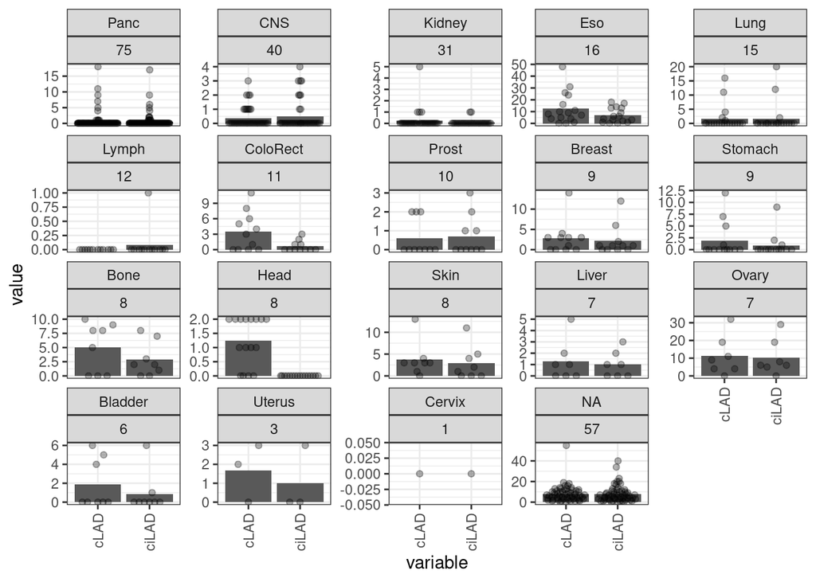

```r
ggplot(MHdel_per_tumor_data,
       aes(variable,value)) +
  stat_summary(geom = "bar",fun = "mean") +
  geom_quasirandom(alpha = 0.3) +
  facet_wrap(~ reorder(tissue, dplyr::desc(tissue_n)) + tissue_n, scales = "free_y") +
  theme_bw() +
  theme(axis.text.x = element_text(angle = 90,
                                   hjust = 1,
                                   vjust = 0.5))
```

#Plot with all the zeroes

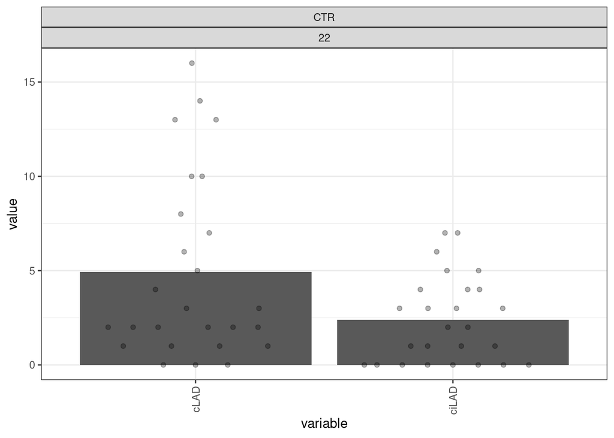

```r
ggplot(MHdel_per_tumor_data %>% filter(driver_mut == "CTR"),
       aes(variable,value)) +
  stat_summary(geom = "bar",fun = "mean") +
  geom_quasirandom(alpha = 0.3) +
  facet_wrap(~ reorder(driver_mut, dplyr::desc(driver_n)) + driver_n) +
  theme_bw() +
  theme(axis.text.x = element_text(angle = 90,
                                   hjust = 1,
                                   vjust = 0.5))
```

#Plot with all the zeroes

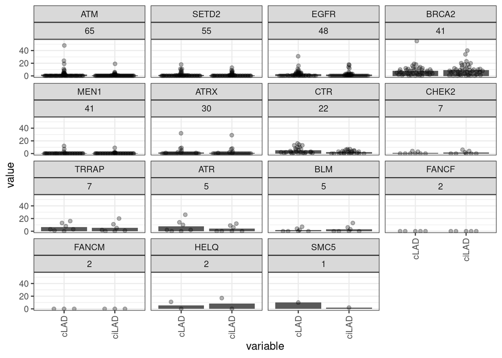

```r
ggplot(MHdel_per_tumor_data,
       aes(variable,value)) +
  stat_summary(geom = "bar",fun = "mean") +
  geom_quasirandom(alpha = 0.3) +
  facet_wrap(~ reorder(driver_mut, dplyr::desc(driver_n)) + driver_n) +
  theme_bw() +
  theme(axis.text.x = element_text(angle = 90,
                                   hjust = 1,
                                   vjust = 0.5))
```

#Calculate number of SV per driver type (same as in paper)

```r
# Prepare data frame per driver mutation.
SV_LAD_values_driver <- MHdel_per_tumor_data %>%
  dplyr::group_by(driver_mut, variable) %>%
  dplyr::summarise(count = sum(value)) %>%
  left_join(drivers_summary)
```

#Calculate control balances

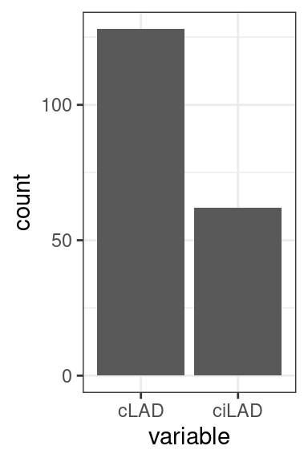

```r
ggplot(SV_LAD_values_driver %>% filter(driver_mut == "CTR")) +
  geom_col(aes(variable, count)) +
  theme_bw()
```

#Plot balances per chromatin type

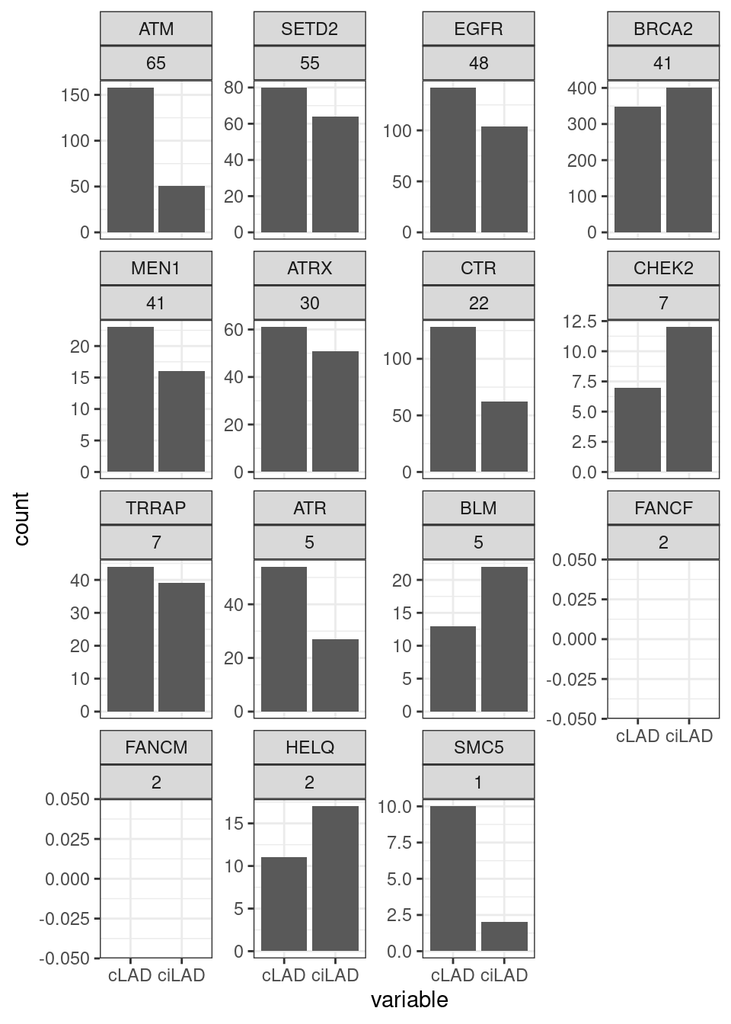

```r
ggplot(SV_LAD_values_driver) +
  geom_col(aes(variable, count)) +
  facet_wrap(~ reorder(driver_mut, dplyr::desc(driver_n)) + driver_n, scales = "free_y") +
  theme_bw()
```

#Calculate Fisher test for each driver mutation

```r
#Prepare data frame for this
fisher_SV_dt <- SV_LAD_values_driver %>%
  reshape2::dcast(driver_mut ~ variable, value.var = "count")

#Calculate a fisher test per driver gene
fisher_test <- map_dfr(driver_desc_order[!driver_desc_order == "CTR"], function(x) {
  fisher_SV_dt %>%
  filter(driver_mut == x | driver_mut == "CTR") %>%
  select(cLAD, ciLAD,driver_mut) %>%
  column_to_rownames(var = "driver_mut") %>%
  fisher.test() %>% broom::tidy() %>% mutate(driver_mut = x)
}) %>% mutate(fdr = p.adjust(p.value, method = "fdr"),
                                             signif = fdr < 0.05)
```

#CONCLUSION: With this approach not so many validate, the differences between tumors are very big. But, we need to work on the statistics and get a nice negative control population. For this, it will be important to get bias measurements per sample.

#Second option: check the median value

```r
# Prepare data frame per driver mutation.
median_SV_LAD_values_driver <- MHdel_per_tumor_data %>%
  dplyr::group_by(driver_mut, variable) %>%
  dplyr::summarise(count = median(value)) %>%
  left_join(drivers_summary)
```

#Calculate control balances

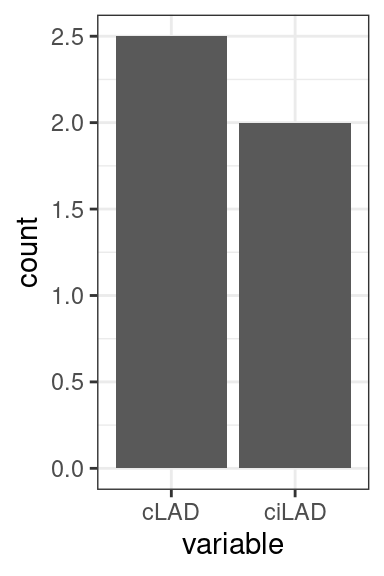

```r
ggplot(median_SV_LAD_values_driver %>% filter(driver_mut == "CTR")) +
  geom_col(aes(variable, count)) +
  theme_bw()
```

#Plot balances per chromatin type

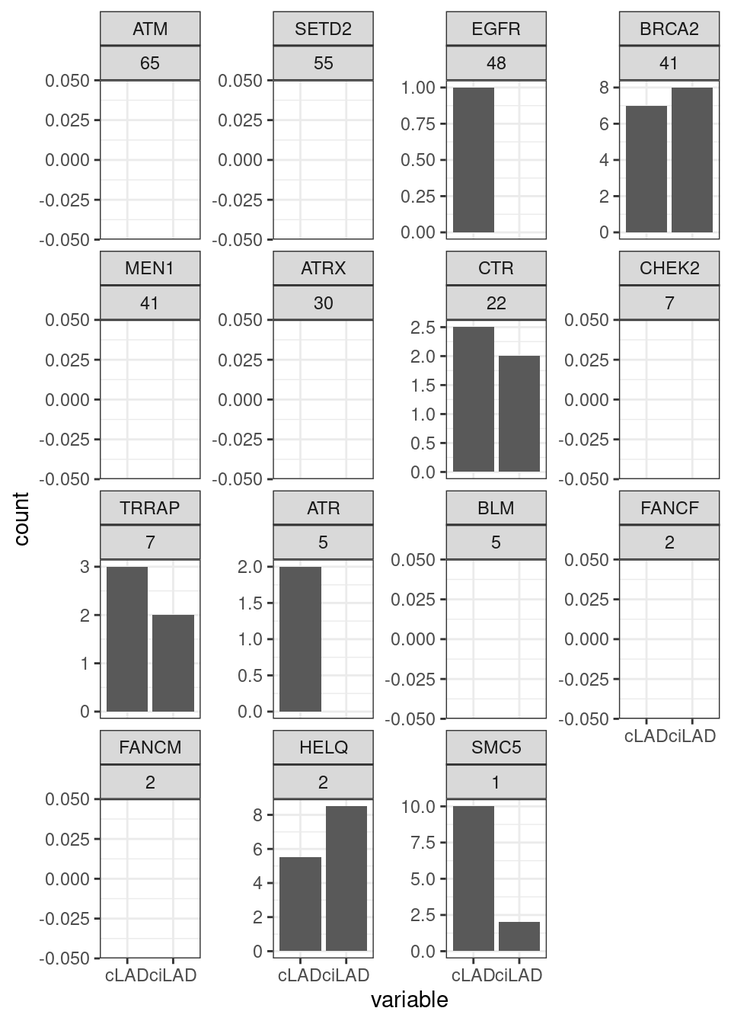

```r
ggplot(median_SV_LAD_values_driver) +
  geom_col(aes(variable, count)) +
  facet_wrap(~ reorder(driver_mut, dplyr::desc(driver_n)) + driver_n, scales = "free_y") +
  theme_bw()
```